# Population Data Management Lab

Alicia Rich

# Format Studbook Data

First, we need to read in our studbook data and clean it up to create a *tidy* format of one master table.

Let’s take a glimpse of our formatted studbook now.

| Studbook ID | Living/Deceased | Father | Mother | Current/Last Location | Sex | Type of Birth | Date of Birth or Capture | Location of Birth or Capture | Date of Death | Location of Death | Age Now or at Death |
| --- | --- | --- | --- | --- | --- | --- | --- | --- | --- | --- | --- |
| 1000 | deceased | 0 | 0 | SKANAKV | Female | Wild Birth/Hatch | NA | VietNam | NA | NA | 0 |
| 1001 | deceased | 0 | 0 | SKANAKV | Female | Wild Birth/Hatch | NA | VietNam | NA | NA | 0 |
| 1002 | deceased | 0 | 0 | HONOLULU | Male | Wild Birth/Hatch | NA | VietNam | 1984-04-28 | HONOLULU | 0 |
| 1003 | deceased | 0 | 0 | HONOLULU | Unknown | Wild Birth/Hatch | NA | VietNam | 1982-01-29 | HONOLULU | 0 |
| 1004 | deceased | 0 | 0 | UNDETERMI | Female | Wild Birth/Hatch | NA | VietNam | NA | NA | 0 |
| 1005 | deceased | 0 | 0 | UNDETERMI | Female | Wild Birth/Hatch | NA | VietNam | NA | NA | 0 |
| 1006 | deceased | 0 | 0 | FITCH H | Male | Wild Birth/Hatch | 1989-01-01 | Undetermined | 1991-06-12 | FITCHH | 2 |
| 1007 | deceased | 0 | 0 | DUKE PRIM | Female | Wild Birth/Hatch | 1983-03-01 | VietNam | 1990-05-12 | DUKEPRIM | 7 |
| 1008 | deceased | 0 | 0 | DUKE PRIM | Female | Wild Birth/Hatch | 1983-03-01 | VietNam | 1998-10-15 | DUKEPRIM | 15 |
| 1009 | deceased | 0 | 0 | DUKE PRIM | Male | Wild Birth/Hatch | 1984-01-01 | VietNam | 1990-09-28 | DUKEPRIM | 6 |

[output cut: 342 more lines]

# Construct Pedigree

Now we will use a package called `pedtools` to create our pedigree objects.

## Add to Summary Table

Let’s look at our studbook with pedigree information added to it.

| Studbook ID | Founder? | Living/Deceased | Father | Mother | Current/Last Location | Sex | Type of Birth | Date of Birth or Capture | Location of Birth or Capture | Date of Death | Location of Death | Age Now or at Death |
| --- | --- | --- | --- | --- | --- | --- | --- | --- | --- | --- | --- | --- |
| 1000 | Yes | deceased | 0 | 0 | SKANAKV | Female | Wild Birth/Hatch | NA | VietNam | NA | NA | 0 |
| 1001 | Yes | deceased | 0 | 0 | SKANAKV | Female | Wild Birth/Hatch | NA | VietNam | NA | NA | 0 |
| 1002 | Yes | deceased | 0 | 0 | HONOLULU | Male | Wild Birth/Hatch | NA | VietNam | 1984-04-28 | HONOLULU | 0 |
| 1003 | Yes | deceased | 0 | 0 | HONOLULU | Unknown | Wild Birth/Hatch | NA | VietNam | 1982-01-29 | HONOLULU | 0 |
| 1004 | Yes | deceased | 0 | 0 | UNDETERMI | Female | Wild Birth/Hatch | NA | VietNam | NA | NA | 0 |
| 1005 | Yes | deceased | 0 | 0 | UNDETERMI | Female | Wild Birth/Hatch | NA | VietNam | NA | NA | 0 |
| 1006 | Yes | deceased | 0 | 0 | FITCH H | Male | Wild Birth/Hatch | 1989-01-01 | Undetermined | 1991-06-12 | FITCHH | 2 |
| 1007 | Yes | deceased | 0 | 0 | DUKE PRIM | Female | Wild Birth/Hatch | 1983-03-01 | VietNam | 1990-05-12 | DUKEPRIM | 7 |
| 1008 | Yes | deceased | 0 | 0 | DUKE PRIM | Female | Wild Birth/Hatch | 1983-03-01 | VietNam | 1998-10-15 | DUKEPRIM | 15 |
| 1009 | Yes | deceased | 0 | 0 | DUKE PRIM | Male | Wild Birth/Hatch | 1984-01-01 | VietNam | 1990-09-28 | DUKEPRIM | 6 |

[output cut: 342 more lines]

Now, we want to visualize a pedigree for just the representation of our living population, so we will subset the pedigree list and plot below.

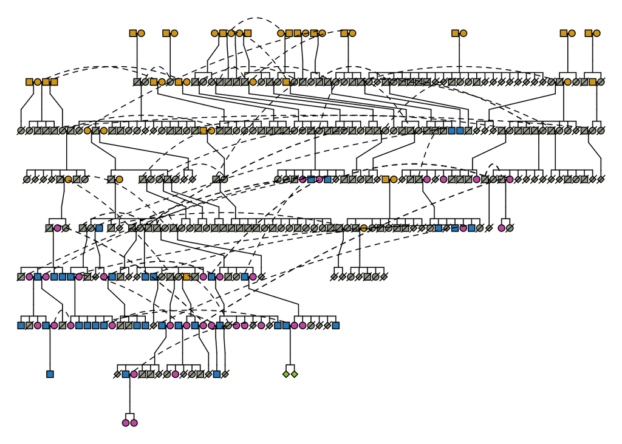

# Generate Detailed Pedigree Statistics

## View Progress

Now we will look at our studbook again with more information added.

| Studbook ID | Founder? | Founder Still Represented? | Living/Deceased | Father | Mother | Current/Last Location | Sex | Type of Birth | Date of Birth or Capture | Location of Birth or Capture | Date of Death | Location of Death | Age Now or at Death |
| --- | --- | --- | --- | --- | --- | --- | --- | --- | --- | --- | --- | --- | --- |
| 1000 | Yes | Yes | deceased | 0 | 0 | SKANAKV | Female | Wild Birth/Hatch | NA | VietNam | NA | NA | 0 |
| 1001 | Yes | Yes | deceased | 0 | 0 | SKANAKV | Female | Wild Birth/Hatch | NA | VietNam | NA | NA | 0 |
| 1002 | Yes | No | deceased | 0 | 0 | HONOLULU | Male | Wild Birth/Hatch | NA | VietNam | 1984-04-28 | HONOLULU | 0 |
| 1003 | Yes | No | deceased | 0 | 0 | HONOLULU | Unknown | Wild Birth/Hatch | NA | VietNam | 1982-01-29 | HONOLULU | 0 |
| 1004 | Yes | No | deceased | 0 | 0 | UNDETERMI | Female | Wild Birth/Hatch | NA | VietNam | NA | NA | 0 |
| 1005 | Yes | No | deceased | 0 | 0 | UNDETERMI | Female | Wild Birth/Hatch | NA | VietNam | NA | NA | 0 |
| 1006 | Yes | No | deceased | 0 | 0 | FITCH H | Male | Wild Birth/Hatch | 1989-01-01 | Undetermined | 1991-06-12 | FITCHH | 2 |
| 1007 | Yes | No | deceased | 0 | 0 | DUKE PRIM | Female | Wild Birth/Hatch | 1983-03-01 | VietNam | 1990-05-12 | DUKEPRIM | 7 |
| 1008 | Yes | Yes | deceased | 0 | 0 | DUKE PRIM | Female | Wild Birth/Hatch | 1983-03-01 | VietNam | 1998-10-15 | DUKEPRIM | 15 |
| 1009 | Yes | No | deceased | 0 | 0 | DUKE PRIM | Male | Wild Birth/Hatch | 1984-01-01 | VietNam | 1990-09-28 | DUKEPRIM | 6 |

[output cut: 342 more lines]

## Calculate Kinship and Other Genetic Stats

## Visualize Summary Table

Now you can view a summary of the statistics we just calculated and compare them to the summaries provided in the example BTP. Use this table to write your own version of a summary (1-2 paragraphs max) like the example in front of you.

| N | n_founder_reps | FGE | delta_F | Ne | Ne_over_N | mean_gen | lambda2 | F_mean | MK | GD |
| --- | --- | --- | --- | --- | --- | --- | --- | --- | --- | --- |
| 54 | 26 | 18.425 | 0.001 | 398.095 | 7.372 | 6.241 | 1.016 | 0.008 | 0.07 | 0.946 |

# Kinship Plots

## Matched Pairs

Finally, we want to look closer at potential breeding pairs to do some match-making, so let’s generate some more pedigree statistics per individual and then visualize a plot of breeding pairs.

[interactive chart not shown]

# Make your Plan and Report

Return to the report you began writing for the overall population statistics. Use all the information provided to match at least one breeding pair for your new exhibit and add a paragraph in which you explain this choice and plan.